# Analisis_suscripciones

## Grafico Usuarios activos vs usuarios cancelados

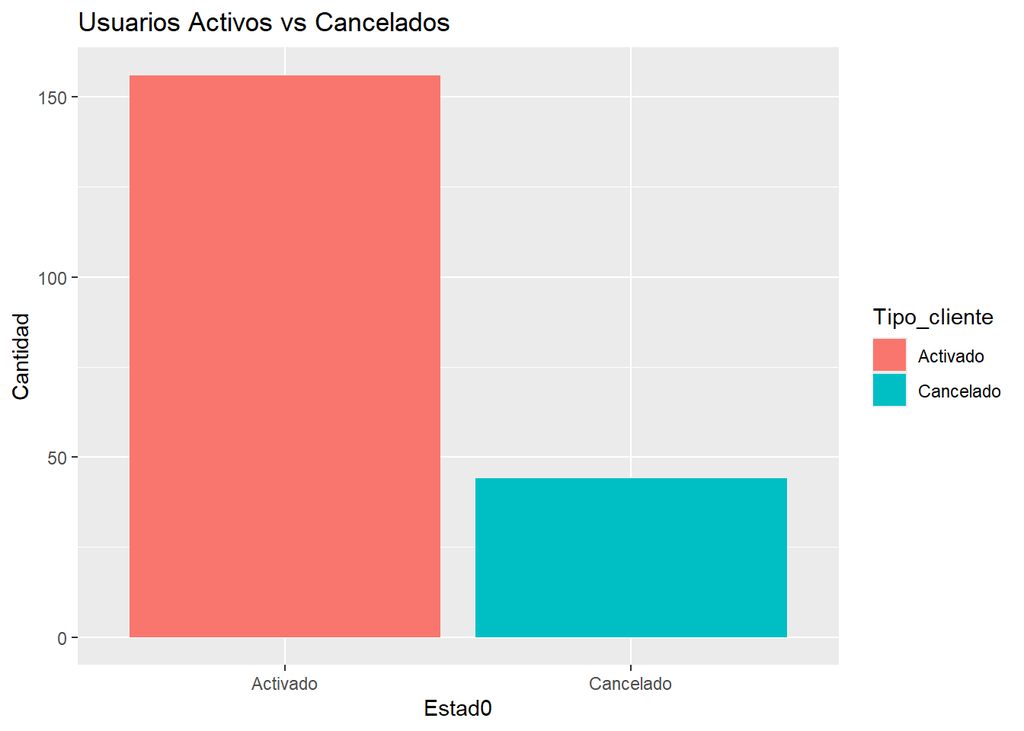

```r
subscriptions%>%
  count(Tipo_cliente)%>%
  ggplot(aes(Tipo_cliente, n, fill = Tipo_cliente))+ geom_col()+ labs(
    title= "Usuarios Activos vs Cancelados",
    x= "Estad0",
    y= "Cantidad"
  )
```

### Interpretación

En este grafico se puede visuaizar la comparativa entre los usuarios activos contra los usuarios cancelados, donde se evidencia una mayor cantidad de usuarios activos que de cancelados en la empresa. COn base a eso, una de las propuestas para la empresa para retener a los usuarios activos, serian de planes de fidelización o promos que ayuden a que el cliente se interese en mantenerse con la empresa.

## Grafico ingresos por plan

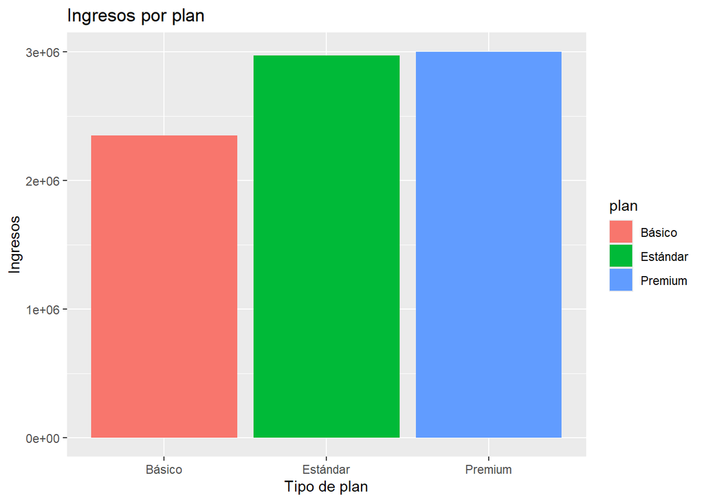

```r
subscriptions%>%
  group_by(plan)%>%
  summarise(
    Ingresos= sum(monthly_fee))%>%
  ggplot(aes(plan, Ingresos, fill = plan)) + geom_col() + labs(
    title = "Ingresos por plan",
    x= "Tipo de plan",
    y= "Ingresos"
  )
```

## Grafico Usuarios por ciudad

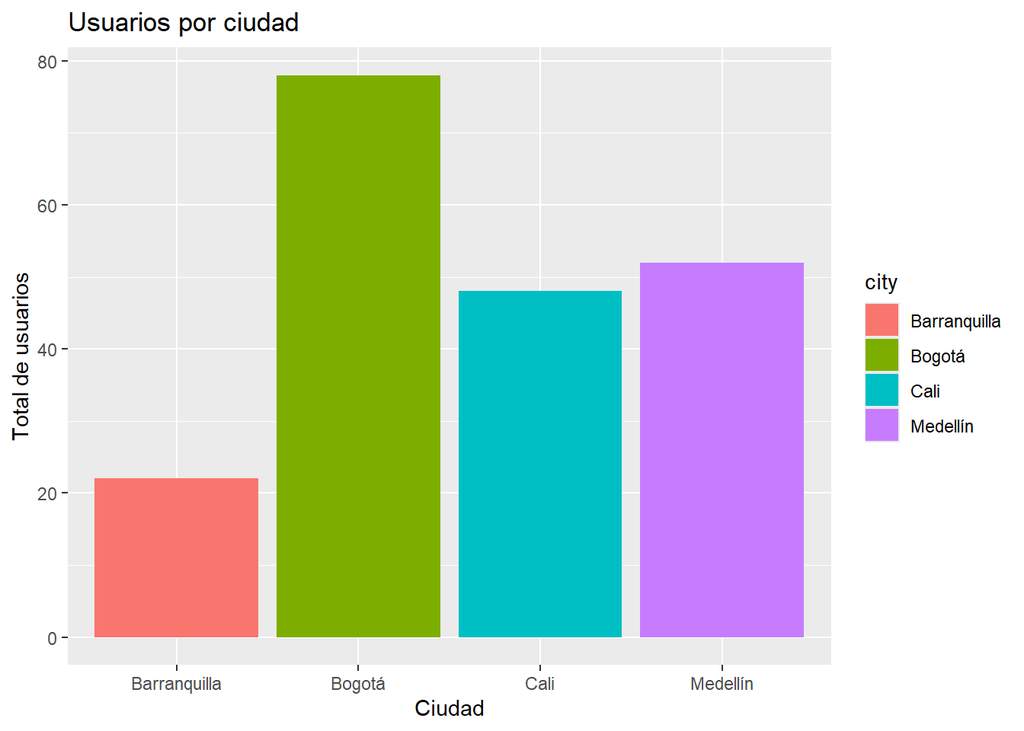

```r
subscriptions%>%
  count(city)%>%
  ggplot(aes(city, n, fill=city))+geom_col()+labs(
    title= "Usuarios por ciudad",
    x= "Ciudad",
    y= "Total de usuarios"
  )
```

### Interpretación

Lo que se puede interpretar con este grafico, es que la ciudad de Bogota es la ciudad donde mayor cantidad de usuarios hay de la empresa, es decir que Bogota es la ciudad que mayor impacto produce la empresa, seguidad de la ciudad de Medellin y Cali. Una de las propuestas que puede hacer la empresa, es hacer una reunión con los usuarios en esas ciudades para llamar más la atención o con el uso de publicidad.